# BT4222 Project Group 16

AY20/21 Semester 2  
Chan Qian Hui | Gan Shi Yong, Thomas | Heng Jie Kai Joven | Ong Ian Jie Joshua | Shervin Lee Jia Ning

**Package Requirements**

- *Exploratory Data Analysis*: numpy, pandas, matplotlib, seaborn
- *Topic Modelling*: nltk, gensim, pyLDAvis
- *Sentiment Analysis*: afinn
- *Regression Models*: pycaret, sklearn, tensorflow

**Check Package Requirements**  
Run the following code chunk to install any missing packages

```python
import os

def import_or_install(package):
    try:
        __import__(package)
    except:
        os.system("pip install " + package)
```

```python
package_list = ['numpy', 'pandas', 'matplotlib', 'seaborn', 'nltk', 'gensim', 'pdLDAvis', 'afinn', 'pycaret', 'sklearn', 'tensorflow']

for package in package_list:
    import_or_install(package)
```

# Data Preparation

```python
import numpy as np
import pandas as pd
import matplotlib.pyplot as plt
import seaborn as sns
```

```python
data = pd.read_csv('Hotel_Reviews_with_tags.csv')
data.head()
```

|  | Unnamed: 0 | Hotel_Address | Additional_Number_of_Scoring | Review_Date | Average_Score | Hotel_Name | Reviewer_Nationality | Negative_Review | Review_Total_Negative_Word_Counts | Total_Number_of_Reviews | ... | Review_Total_Positive_Word_Counts | Total_Number_of_Reviews_Reviewer_Has_Given | Reviewer_Score | Tags | days_since_review | lat | lng | Trip_purpose | trip_companions | room_type |
| --- | --- | --- | --- | --- | --- | --- | --- | --- | --- | --- | --- | --- | --- | --- | --- | --- | --- | --- | --- | --- | --- |
| 0 | 0 | s Gravesandestraat 55 Oost 1092 AA Amsterdam ... | 194 | 8/3/2017 | 7.7 | Hotel Arena | Russia | I am so angry that i made this post available... | 397 | 1403 | ... | 11 | 7 | 2.9 | [' Leisure trip ', ' Couple ', ' Duplex Double... | 0 days | 52.360576 | 4.915968 | Leisure | Couple | Double |
| 1 | 1 | s Gravesandestraat 55 Oost 1092 AA Amsterdam ... | 194 | 8/3/2017 | 7.7 | Hotel Arena | Ireland | No Negative | 0 | 1403 | ... | 105 | 7 | 7.5 | [' Leisure trip ', ' Couple ', ' Duplex Double... | 0 days | 52.360576 | 4.915968 | Leisure | Couple | Double |
| 2 | 2 | s Gravesandestraat 55 Oost 1092 AA Amsterdam ... | 194 | 7/31/2017 | 7.7 | Hotel Arena | Australia | Rooms are nice but for elderly a bit difficul... | 42 | 1403 | ... | 21 | 9 | 7.1 | [' Leisure trip ', ' Family with young childre... | 3 days | 52.360576 | 4.915968 | Leisure | Family | Double |
| 3 | 3 | s Gravesandestraat 55 Oost 1092 AA Amsterdam ... | 194 | 7/31/2017 | 7.7 | Hotel Arena | United Kingdom | My room was dirty and I was afraid to walk ba... | 210 | 1403 | ... | 26 | 1 | 3.8 | [' Leisure trip ', ' Solo traveler ', ' Duplex... | 3 days | 52.360576 | 4.915968 | Leisure | Solo | Double |
| 4 | 4 | s Gravesandestraat 55 Oost 1092 AA Amsterdam ... | 194 | 7/24/2017 | 7.7 | Hotel Arena | New Zealand | You When I booked with your company on line y... | 140 | 1403 | ... | 8 | 3 | 6.7 | [' Leisure trip ', ' Couple ', ' Suite ', ' St... | 10 days | 52.360576 | 4.915968 | Leisure | Couple | Suite |

5 rows × 21 columns

```python
data.drop(columns = ['Unnamed: 0', 'Tags'], inplace = True)
```

```python
data.columns
```

```
Index(['Hotel_Address', 'Additional_Number_of_Scoring', 'Review_Date',
       'Average_Score', 'Hotel_Name', 'Reviewer_Nationality',
       'Negative_Review', 'Review_Total_Negative_Word_Counts',
       'Total_Number_of_Reviews', 'Positive_Review',
       'Review_Total_Positive_Word_Counts',
       'Total_Number_of_Reviews_Reviewer_Has_Given', 'Reviewer_Score',
       'days_since_review', 'lat', 'lng', 'Trip_purpose', 'trip_companions',
       'room_type'],
      dtype='object')
```

```python
data.shape
```

```
(515738, 19)
```

```python
data['Hotel_Name'].value_counts()
```

```
Britannia International Hotel Canary Wharf           4789
Strand Palace Hotel                                  4256
Park Plaza Westminster Bridge London                 4169
Copthorne Tara Hotel London Kensington               3578
DoubleTree by Hilton Hotel London Tower of London    3212
                                                     ...
Le Lavoisier                                           12
Boundary Rooms Suites                                  12
Mercure Paris Porte d Orleans                          10
Hotel Wagner                                           10
Hotel Gallitzinberg                                     8
Name: Hotel_Name, Length: 1492, dtype: int64
```

# Exploratory Data Analysis

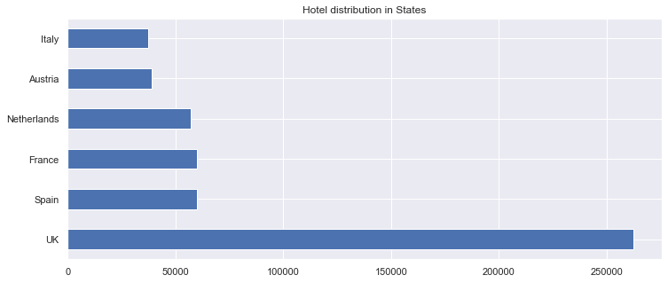

```python
sns.set()
data.Hotel_Address = data.Hotel_Address.str.replace('United Kingdom','UK')
data['State'] = data.Hotel_Address.apply(lambda x: x.split(' ')[-1])

# Hotel distribution in Europe
plt.figure(figsize = (12, 5))
plt.title('Hotel distribution in States')
data.State.value_counts().plot.barh()
```

```python
count_neg = data.loc[data["Negative_Review"]!= "No Negative"]
count_pos = data.loc[data["Positive_Review"]!= "No Positive"]
print(len(count_neg), len(count_pos))
```

```
387848 479792
```

## Dataset Distribution

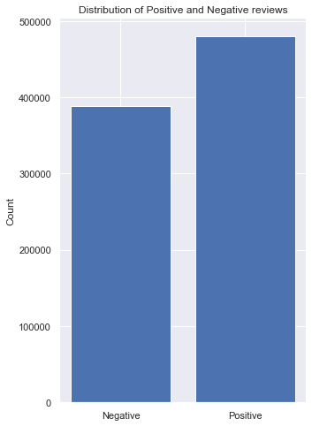

```python
sns.set()

x = ["Negative", "Positive"]
y = [len(count_neg), len(count_pos)]

plt.figure(figsize = (5, 8))
plt.bar(x,y)
plt.title("Distribution of Positive and Negative reviews")
plt.ylabel("Count")
```

```python
df_temp = data[["Additional_Number_of_Scoring", "Average_Score", "Review_Total_Negative_Word_Counts", "Total_Number_of_Reviews", "Review_Total_Positive_Word_Counts","Total_Number_of_Reviews_Reviewer_Has_Given", "Reviewer_Score"]]
df_temp.describe()
```

|  | Additional_Number_of_Scoring | Average_Score | Review_Total_Negative_Word_Counts | Total_Number_of_Reviews | Review_Total_Positive_Word_Counts | Total_Number_of_Reviews_Reviewer_Has_Given | Reviewer_Score |
| --- | --- | --- | --- | --- | --- | --- | --- |
| count | 515738.000000 | 515738.000000 | 515738.000000 | 515738.000000 | 515738.000000 | 515738.000000 | 515738.000000 |
| mean | 498.081836 | 8.397487 | 18.539450 | 2743.743944 | 17.776458 | 7.166001 | 8.395077 |
| std | 500.538467 | 0.548048 | 29.690831 | 2317.464868 | 21.804185 | 11.040228 | 1.637856 |
| min | 1.000000 | 5.200000 | 0.000000 | 43.000000 | 0.000000 | 1.000000 | 2.500000 |
| 25% | 169.000000 | 8.100000 | 2.000000 | 1161.000000 | 5.000000 | 1.000000 | 7.500000 |
| 50% | 341.000000 | 8.400000 | 9.000000 | 2134.000000 | 11.000000 | 3.000000 | 8.800000 |
| 75% | 660.000000 | 8.800000 | 23.000000 | 3613.000000 | 22.000000 | 8.000000 | 9.600000 |
| max | 2682.000000 | 9.800000 | 408.000000 | 16670.000000 | 395.000000 | 355.000000 | 10.000000 |

## Correlation of Numeric Variables

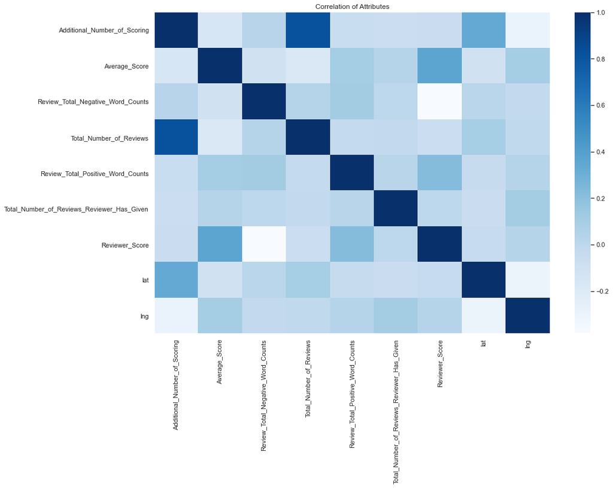

```python
plt.figure(figsize = (15, 10))
ax = sns.heatmap(data.corr(), cmap = 'Blues',annot = False)
ax.set_title("Correlation of Attributes")
ax
```

## Top 20 Hotels by Number of Reviews

```python
data[['Hotel_Name','Average_Score','Total_Number_of_Reviews']].drop_duplicates().sort_values(by ='Total_Number_of_Reviews',ascending = False)[:20]
```

|  | Hotel_Name | Average_Score | Total_Number_of_Reviews |
| --- | --- | --- | --- |
| 488409 | Hotel Da Vinci | 8.1 | 16670 |
| 504027 | Park Plaza Westminster Bridge London | 8.7 | 12158 |
| 496065 | Hotel degli Arcimboldi | 8.3 | 10842 |
| 164259 | Strand Palace Hotel | 8.1 | 9568 |
| 63942 | Britannia International Hotel Canary Wharf | 7.1 | 9086 |
| 311000 | Best Western Premier Hotel Couture | 8.7 | 8177 |
| 509232 | The Student Hotel Amsterdam City | 8.7 | 7656 |
| 379680 | Golden Tulip Amsterdam West | 8.5 | 7586 |
| 236055 | DoubleTree by Hilton Hotel London Tower of London | 8.7 | 7491 |
| 404728 | Glam Milano | 8.8 | 7371 |
| 309843 | Jaz Amsterdam | 8.9 | 7108 |
| 440985 | Copthorne Tara Hotel London Kensington | 8.1 | 7105 |
| 111930 | Hilton London Metropole | 7.5 | 6977 |
| 278418 | Catalonia Atenas | 7.9 | 6792 |
| 127024 | Park Grand Paddington Court | 8.1 | 6608 |
| 140872 | Blakemore Hyde Park | 8.5 | 6596 |
| 8301 | Grand Royale London Hyde Park | 7.7 | 6539 |
| 202331 | Holiday Inn Paris Gare de l Est | 7.9 | 6511 |
| 378521 | Leonardo Hotel Vienna | 8.1 | 6373 |
| 5257 | Park Plaza County Hall London | 8.4 | 6117 |

# Topic Modelling

## Text Preprocessing

```python
import nltk
import gensim.models as gs
from gensim.corpora.dictionary import Dictionary
```

```python
english_stops = nltk.corpus.stopwords.words('english')
```

```python
def preprocess_positive_text(text):

    # Convert all text to lowercase
    lowercase_text = text.lower()

    # Tokenize sentences into individual word tokens
    tokens = nltk.tokenize.word_tokenize(lowercase_text)

    # Remove non-alphabetical tokens
    alpha = [t for t in tokens if t.isalpha() == True and t != 'positive' and len(t) >= 2]

    # Remove stop words
    nstop = [t for t in alpha if t not in english_stops]

    # Lemmatize all tokens
    words = [nltk.stem.WordNetLemmatizer().lemmatize(t) for t in nstop]

    return words
```

```python
def preprocess_negative_text(text):

    # Convert all text to lowercase
    lowercase_text = text.lower()

    # Tokenize sentences into individual word tokens
    tokens = nltk.tokenize.word_tokenize(lowercase_text)

    # Remove non-alphabetical tokens
    alpha = [t for t in tokens if t.isalpha() == True and t != 'negative' and len(t) >= 2]

    # Remove stop words
    nstop = [t for t in alpha if t not in english_stops]

    # Lemmatize all tokens
    words = [nltk.stem.WordNetLemmatizer().lemmatize(t) for t in nstop]

    return words
```

### Tokenize Positive and Negative Reviews

```python
positive_tokens = data['Positive_Review'].apply(preprocess_positive_text)
positive_tokens
```

```
0                         [park, outside, hotel, beautiful]
1         [real, complaint, hotel, great, great, locatio...
2         [location, good, staff, ok, cute, hotel, break...
3         [great, location, nice, surroundings, bar, res...
4          [amazing, location, building, romantic, setting]
                                ...
515733                                           [location]
515734                 [breakfast, ok, got, earlier, check]
515735                                                   []
515736    [room, enormous, really, comfortable, believe,...
515737                                        [staff, kind]
Name: Positive_Review, Length: 515738, dtype: object
```

```python
negative_tokens = data['Negative_Review'].apply(preprocess_negative_text)
negative_tokens
```

```
0         [angry, made, post, available, via, possible, ...
1                                                        []
2         [room, nice, elderly, bit, difficult, room, tw...
3         [room, dirty, afraid, walk, barefoot, floor, l...
4         [booked, company, line, showed, picture, room,...
                                ...
515733           [trolly, staff, help, take, luggage, room]
515734                          [hotel, look, like, surely]
515735     [ac, useless, hot, week, vienna, gave, hot, air]
515736                                                   []
515737                            [floor, work, free, wife]
Name: Negative_Review, Length: 515738, dtype: object
```

### Most Common Words

```python
from collections import Counter
```

```python
positive_tokens_flattened = [i for j in positive_tokens for i in j]
len(positive_tokens_flattened)
```

```
4899838
```

```python
negative_tokens_flattened = [i for j in negative_tokens for i in j]
len(negative_tokens_flattened)
```

```
4439973
```

```python
# Count the most common tokens in positive reviews
Counter(positive_tokens_flattened).most_common(10)
```

```
[('staff', 196634),
 ('location', 193607),
 ('room', 181116),
 ('hotel', 130109),
 ('good', 112387),
 ('great', 105651),
 ('breakfast', 86374),
 ('friendly', 85354),
 ('helpful', 76183),
 ('nice', 69453)]
```

```python
# Count the most common tokens in negative reviews
Counter(negative_tokens_flattened).most_common(10)
```

```
[('room', 210828),
 ('hotel', 80413),
 ('breakfast', 59224),
 ('small', 49885),
 ('staff', 39979),
 ('nothing', 38789),
 ('bed', 37393),
 ('would', 32291),
 ('could', 32079),
 ('one', 28982)]
```

## Topic Modelling with Gensim

### Preparating Tokens for LDA

```python
# Create Dictionary from Positive Tokens
dict_positive = Dictionary(positive_tokens)

# Create corpus from Dictionary
positive_corpus = [dict_positive.doc2bow(review) for review in positive_tokens]
```

```python
# Create Dictionary from Negative Tokens
dict_negative = Dictionary(negative_tokens)

# Create corpus from Dictionary
negative_corpus = [dict_negative.doc2bow(review) for review in negative_tokens]
```

### LDA Model Function to Get Coherence Score

```python
def lda_topic_optimise(corpus, dictionary, tokens, n):

    # Create LDA model from Dictionary and Corpus
    lda_model = gs.LdaMulticore(corpus,
                                num_topics = n,
                                id2word = dictionary,
                                workers = 4,
                                iterations = 200,
                                random_state = 421)

    # Compute Coherence Value for Positive Model
    coherence_model = gs.CoherenceModel(model = lda_model,
                                        texts = tokens,
                                        dictionary = dictionary,
                                        coherence = 'c_v')

    return coherence_model.get_coherence()
```

### Determine Best Number of Topics

Warning! This section takes about ~30 mins to fully run.

```python
# Define number of topics to investigate
n = [2, 3, 4, 5, 6, 7, 8, 9, 10]
```

```python
positive_score = [lda_topic_optimise(positive_corpus, dict_positive, positive_tokens, i) for i in n]
```

```python
negative_score = [lda_topic_optimise(negative_corpus, dict_negative, negative_tokens, i) for i in n]
```

```python
# View coherence score results in DataFrame
score_results = pd.DataFrame({'No. of Topics': n,
                              'Positive Reviews Coherence Score':  positive_score,
                              'Negative Reviews Coherence Score':  negative_score})
score_results
```

|  | No. of Topics | Positive Reviews Coherence Score | Negative Reviews Coherence Score |
| --- | --- | --- | --- |
| 0 | 2 | 0.516239 | 0.550757 |
| 1 | 3 | 0.537964 | 0.585723 |
| 2 | 4 | 0.557047 | 0.611687 |
| 3 | 5 | 0.565332 | 0.626502 |
| 4 | 6 | 0.599508 | 0.637172 |
| 5 | 7 | 0.598924 | 0.667307 |
| 6 | 8 | 0.613454 | 0.657916 |
| 7 | 9 | 0.626242 | 0.670439 |
| 8 | 10 | 0.610315 | 0.658070 |

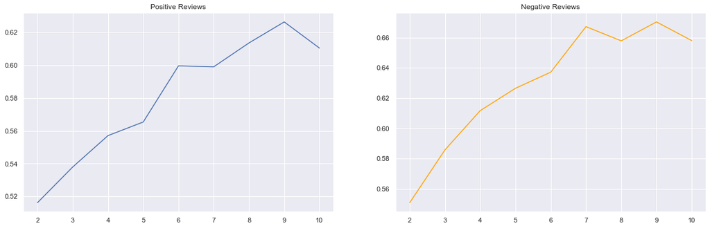

```python
# Visualise coherence score results
plt.rcParams['figure.figsize'] = [20, 6]

fig, axs = plt.subplots(1, 2)

axs[0].plot(score_results['No. of Topics'], score_results['Positive Reviews Coherence Score'])
axs[0].set_title('Positive Reviews')

axs[1].plot(score_results['No. of Topics'], score_results['Negative Reviews Coherence Score'], color = 'orange')
axs[1].set_title('Negative Reviews')

plt.show()
```

### Building Model with Optimal Number of Topics

```python
import warnings
```

```python
warnings.filterwarnings("ignore", category = DeprecationWarning)
warnings.simplefilter("ignore")
```

```python
positive_model = gs.LdaMulticore(positive_corpus,
                                 num_topics = 9,
                                 id2word = dict_positive,
                                 workers = 4,
                                 iterations = 200,
                                 random_state = 421)
```

```python
negative_model = gs.LdaMulticore(negative_corpus,
                                 num_topics = 7,
                                 id2word = dict_negative,
                                 workers = 4,
                                 iterations = 200,
                                 random_state = 421)
```

```python
# Print topics in positive_models
topics_p = positive_model.print_topics(num_words = 5)

for topic in topics_p:
    print(topic)
```

```
(0, '0.153*"good" + 0.122*"breakfast" + 0.056*"location" + 0.045*"room" + 0.044*"staff"')
(1, '0.168*"location" + 0.082*"great" + 0.066*"hotel" + 0.045*"excellent" + 0.031*"staff"')
(2, '0.047*"hotel" + 0.037*"everything" + 0.020*"room" + 0.018*"time" + 0.014*"check"')
(3, '0.088*"room" + 0.019*"pool" + 0.018*"view" + 0.017*"nice" + 0.016*"bathroom"')
(4, '0.027*"room" + 0.026*"staff" + 0.023*"hotel" + 0.021*"u" + 0.020*"stay"')
(5, '0.140*"bed" + 0.110*"comfortable" + 0.106*"room" + 0.061*"clean" + 0.047*"comfy"')
(6, '0.178*"staff" + 0.098*"friendly" + 0.091*"helpful" + 0.056*"location" + 0.052*"great"')
(7, '0.037*"station" + 0.036*"location" + 0.035*"close" + 0.032*"hotel" + 0.022*"metro"')
(8, '0.058*"staff" + 0.028*"helpful" + 0.024*"hotel" + 0.022*"friendly" + 0.019*"free"')
```

```python
# Print topics in negative_models
topics_n = negative_model.print_topics(num_words = 5)

for topic in topics_n:
    print(topic)
```

```
(0, '0.026*"hotel" + 0.020*"shower" + 0.019*"room" + 0.018*"pool" + 0.017*"location"')
(1, '0.060*"room" + 0.022*"staff" + 0.016*"air" + 0.014*"water" + 0.013*"coffee"')
(2, '0.097*"breakfast" + 0.030*"expensive" + 0.027*"wifi" + 0.025*"room" + 0.021*"poor"')
(3, '0.043*"hotel" + 0.035*"room" + 0.012*"u" + 0.012*"booking" + 0.011*"would"')
(4, '0.023*"day" + 0.021*"check" + 0.018*"staff" + 0.018*"time" + 0.016*"parking"')
(5, '0.124*"room" + 0.059*"bed" + 0.057*"small" + 0.021*"bathroom" + 0.013*"double"')
(6, '0.087*"nothing" + 0.037*"room" + 0.026*"noise" + 0.021*"night" + 0.021*"hotel"')
```

## Visualise Topic Modelling with pyLDAvis

Warning! This section takes ~5 to 10 mins to fully run.

```python
import pyLDAvis.gensim_models
```

```python
warnings.filterwarnings("ignore", category = DeprecationWarning)
```

```python
positive_display = pyLDAvis.gensim_models.prepare(positive_model,
                                           positive_corpus,
                                           dict_positive,
                                           sort_topics = False)
```

```python
pyLDAvis.display(positive_display)
```

[interactive chart not shown]

```python
negative_display = pyLDAvis.gensim_models.prepare(negative_model,
                                           negative_corpus,
                                           dict_negative,
                                           sort_topics = False)
```

```python
pyLDAvis.display(negative_display)
```

[interactive chart not shown]

## Predicting Topic For Each Document (Review)

Warning! This section takes ~10 mins to fully run.

```python
def get_topic(token, dictionary, model):

    if len(token) > 0:
        # Create dictionary of bag-of-words from tokens
        doc_bow = dictionary.doc2bow(token)

        # Determine topic distribution based on trained model
        topics  = sorted(model[doc_bow], key = lambda x: x[1], reverse = True)

        # Return topic with highest probability
        return topics[0][0]

    else:
        return np.nan
```

```python
# Generate topic with highest score for all positive reviews
positive_topic = []

for i in range(0, len(positive_tokens)):

    positive_topic.append(get_topic(positive_tokens[i], dict_positive, positive_model))
```

```python
# Generate topic with highest score for all negative reviews
negative_topic = []

for i in range(0, len(negative_tokens)):

    negative_topic.append(get_topic(negative_tokens[i], dict_negative, negative_model))
```

```python
# Add list of positive and negative topics as feature
data['Positive_Topic'] = positive_topic
data['Negative_Topic'] = negative_topic
```

```python
data['Positive_Topic'].value_counts()
```

```
6.0    82537
1.0    79533
7.0    73528
0.0    57886
3.0    43829
5.0    43579
2.0    41552
4.0    34462
8.0    22093
Name: Positive_Topic, dtype: int64
```

```python
data['Negative_Topic'].value_counts()
```

```
6.0    68624
5.0    68339
2.0    58832
1.0    57773
3.0    49550
0.0    48165
4.0    33339
Name: Negative_Topic, dtype: int64
```

## Business Insights and Applications of Topic Modelling

```python
data_2 = data[['Hotel_Name', 'Positive_Topic', 'Negative_Topic']]
data_2.head()
```

|  | Hotel_Name | Positive_Topic | Negative_Topic |
| --- | --- | --- | --- |
| 0 | Hotel Arena | 7.0 | 3.0 |
| 1 | Hotel Arena | 4.0 | NaN |
| 2 | Hotel Arena | 0.0 | 1.0 |
| 3 | Hotel Arena | 3.0 | 0.0 |
| 4 | Hotel Arena | 6.0 | 3.0 |

```python
# Remove hotels with less than 100 reviews
hotel_list = list(data_2['Hotel_Name'].value_counts()[data_2['Hotel_Name'].value_counts() > 100].index)
len(hotel_list)
```

```
1074
```

```python
# Group by Hotel and Positive_Topic
hotel_positive = data_2[['Hotel_Name', 'Positive_Topic']]\
                       .dropna()\
                       .groupby(['Hotel_Name', 'Positive_Topic'])\
                       .size()\
                       .reset_index(name = 'Counts')
```

```python
hotel_positive
```

|  | Hotel_Name | Positive_Topic | Counts |
| --- | --- | --- | --- |
| 0 | 11 Cadogan Gardens | 0.0 | 9 |
| 1 | 11 Cadogan Gardens | 1.0 | 25 |
| 2 | 11 Cadogan Gardens | 2.0 | 24 |
| 3 | 11 Cadogan Gardens | 3.0 | 9 |
| 4 | 11 Cadogan Gardens | 4.0 | 24 |
| ... | ... | ... | ... |
| 13179 | pentahotel Vienna | 4.0 | 7 |
| 13180 | pentahotel Vienna | 5.0 | 9 |
| 13181 | pentahotel Vienna | 6.0 | 18 |
| 13182 | pentahotel Vienna | 7.0 | 10 |
| 13183 | pentahotel Vienna | 8.0 | 5 |

13184 rows × 3 columns

```python
# Group by Hotel and Negative Topic
hotel_negative = data_2[['Hotel_Name', 'Negative_Topic']]\
                       .dropna()\
                       .groupby(['Hotel_Name', 'Negative_Topic'])\
                       .size()\
                       .reset_index(name = 'Counts')
```

```python
hotel_negative
```

|  | Hotel_Name | Negative_Topic | Counts |
| --- | --- | --- | --- |
| 0 | 11 Cadogan Gardens | 0.0 | 10 |
| 1 | 11 Cadogan Gardens | 1.0 | 18 |
| 2 | 11 Cadogan Gardens | 2.0 | 12 |
| 3 | 11 Cadogan Gardens | 3.0 | 17 |
| 4 | 11 Cadogan Gardens | 4.0 | 8 |
| ... | ... | ... | ... |
| 10303 | pentahotel Vienna | 2.0 | 26 |
| 10304 | pentahotel Vienna | 3.0 | 13 |
| 10305 | pentahotel Vienna | 4.0 | 10 |
| 10306 | pentahotel Vienna | 5.0 | 9 |
| 10307 | pentahotel Vienna | 6.0 | 15 |

10308 rows × 3 columns

### Examine Topics for a Random Hotel

```python
# Remove hotels with less than 1000 reviews
hotel_list = list(data_2['Hotel_Name'].value_counts()[data_2['Hotel_Name'].value_counts() > 1000].index)
len(hotel_list)
```

```
101
```

```python
import random
```

```python
random.seed(4)
```

```python
# Randomly sample a hotel from this list
random_hotel = random.sample(hotel_list, 1)
random_hotel
```

```
['Club Quarters Hotel St Paul s']
```

```python
positive_random_analysis = hotel_positive[hotel_positive['Hotel_Name'] == random_hotel[0]]
positive_random_analysis
```

|  | Hotel_Name | Positive_Topic | Counts |
| --- | --- | --- | --- |
| 2053 | Club Quarters Hotel St Paul s | 0.0 | 133 |
| 2054 | Club Quarters Hotel St Paul s | 1.0 | 322 |
| 2055 | Club Quarters Hotel St Paul s | 2.0 | 92 |
| 2056 | Club Quarters Hotel St Paul s | 3.0 | 194 |
| 2057 | Club Quarters Hotel St Paul s | 4.0 | 61 |
| 2058 | Club Quarters Hotel St Paul s | 5.0 | 103 |
| 2059 | Club Quarters Hotel St Paul s | 6.0 | 196 |
| 2060 | Club Quarters Hotel St Paul s | 7.0 | 262 |
| 2061 | Club Quarters Hotel St Paul s | 8.0 | 160 |

```python
plt.rcParams['figure.figsize'] = [8, 6]
```

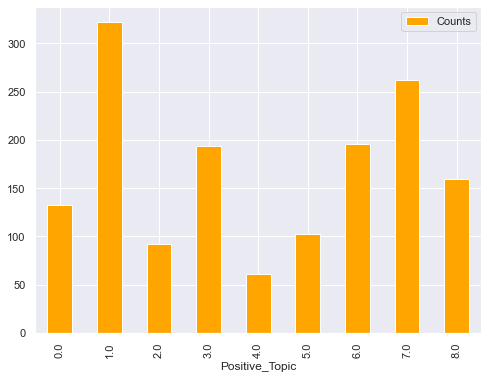

```python
positive_random_analysis.plot(x = 'Positive_Topic', y = 'Counts', kind = 'bar', color = 'orange')
```

```python
negative_random_analysis = hotel_negative[hotel_negative['Hotel_Name'] == random_hotel[0]]
negative_random_analysis
```

|  | Hotel_Name | Negative_Topic | Counts |
| --- | --- | --- | --- |
| 1604 | Club Quarters Hotel St Paul s | 0.0 | 117 |
| 1605 | Club Quarters Hotel St Paul s | 1.0 | 226 |
| 1606 | Club Quarters Hotel St Paul s | 2.0 | 102 |
| 1607 | Club Quarters Hotel St Paul s | 3.0 | 116 |
| 1608 | Club Quarters Hotel St Paul s | 4.0 | 85 |
| 1609 | Club Quarters Hotel St Paul s | 5.0 | 210 |
| 1610 | Club Quarters Hotel St Paul s | 6.0 | 310 |

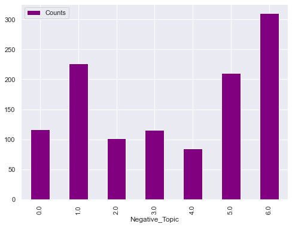

```python
negative_random_analysis.plot(x = 'Negative_Topic', y = 'Counts', kind = 'bar', color = 'purple')
```

# Sentiment Analysis with AFINN

Warning! This section takes around ~15 mins to fully run.

```python
from afinn import Afinn
```

```python
afinn = Afinn()
afinn_scores_pos = [afinn.score(text) for text in data['Positive_Review']]
afinn_scores_neg = [afinn.score(text) for text in data['Negative_Review']]
```

```python
# Add positive and negative sentiments as feature
data['pos_afinn'] = afinn_scores_pos
data['neg_afinn'] = afinn_scores_neg
```

## Insights into Sentiment by Hotels

```python
df_pos = data[['Hotel_Name','Positive_Topic','pos_afinn']].sort_values(by = 'Hotel_Name', ascending = False)
df_pos
```

|  | Hotel_Name | Positive_Topic | pos_afinn |
| --- | --- | --- | --- |
| 376898 | pentahotel Vienna | 6.0 | 0.0 |
| 376882 | pentahotel Vienna | 0.0 | 3.0 |
| 376880 | pentahotel Vienna | 0.0 | 6.0 |
| 376879 | pentahotel Vienna | 1.0 | 0.0 |
| 376878 | pentahotel Vienna | 2.0 | 0.0 |
| ... | ... | ... | ... |
| 33808 | 11 Cadogan Gardens | 3.0 | 3.0 |
| 33807 | 11 Cadogan Gardens | 1.0 | 3.0 |
| 33806 | 11 Cadogan Gardens | 6.0 | 7.0 |
| 33805 | 11 Cadogan Gardens | 8.0 | 7.0 |
| 33818 | 11 Cadogan Gardens | 5.0 | 6.0 |

515738 rows × 3 columns

```python
df_pos_hotel = df_pos.groupby(["Hotel_Name", "Positive_Topic"], dropna = True).mean()
df_pos_hotel[:18]
```

| Hotel_Name | Positive_Topic | pos_afinn |
| --- | --- | --- |
| 11 Cadogan Gardens | 0.0 | 7.000000 |
|  | 1.0 | 5.640000 |
|  | 2.0 | 6.958333 |
|  | 3.0 | 8.111111 |
|  | 4.0 | 7.750000 |
|  | 5.0 | 4.111111 |
|  | 6.0 | 5.171429 |
|  | 7.0 | 8.000000 |
|  | 8.0 | 6.000000 |
| 1K Hotel | 0.0 | 6.333333 |
|  | 1.0 | 5.277778 |
|  | 2.0 | 7.500000 |
|  | 3.0 | 3.352941 |
|  | 4.0 | 5.888889 |
|  | 5.0 | 3.739130 |
|  | 6.0 | 4.125000 |
|  | 7.0 | 7.312500 |
|  | 8.0 | 6.250000 |

```python
df_neg = data[['Hotel_Name','Negative_Topic','neg_afinn']].sort_values(by = 'Hotel_Name', ascending = False)
df_neg
```

|  | Hotel_Name | Negative_Topic | neg_afinn |
| --- | --- | --- | --- |
| 376898 | pentahotel Vienna | 1.0 | -1.0 |
| 376882 | pentahotel Vienna | 3.0 | 0.0 |
| 376880 | pentahotel Vienna | 6.0 | -2.0 |
| 376879 | pentahotel Vienna | NaN | -3.0 |
| 376878 | pentahotel Vienna | 2.0 | 0.0 |
| ... | ... | ... | ... |
| 33808 | 11 Cadogan Gardens | 2.0 | 0.0 |
| 33807 | 11 Cadogan Gardens | NaN | -3.0 |
| 33806 | 11 Cadogan Gardens | 0.0 | 0.0 |
| 33805 | 11 Cadogan Gardens | NaN | -3.0 |
| 33818 | 11 Cadogan Gardens | 0.0 | 0.0 |

515738 rows × 3 columns

```python
df_neg_hotel = df_neg.groupby(["Hotel_Name", "Negative_Topic"], dropna = True).mean()
df_neg_hotel[:14]
```

| Hotel_Name | Negative_Topic | neg_afinn |
| --- | --- | --- |
| 11 Cadogan Gardens | 0.0 | -0.200000 |
|  | 1.0 | -1.611111 |
|  | 2.0 | 0.500000 |
|  | 3.0 | 0.176471 |
|  | 4.0 | -0.250000 |
|  | 5.0 | 0.833333 |
|  | 6.0 | -0.666667 |
| 1K Hotel | 0.0 | -1.035714 |
|  | 1.0 | -0.692308 |
|  | 2.0 | -0.736842 |
|  | 3.0 | -2.750000 |
|  | 4.0 | -1.461538 |
|  | 5.0 | -0.500000 |
|  | 6.0 | -0.933333 |

```python
# Write data to file for consistency
# data.to_csv('Hotel_Reviews_with_text_features.csv', index = False)
```

# Supervised Learning

## Data Processing and Aggregation of Results

```python
# Read in feature engineered data if needed
# data = pd.read_csv('Hotel_Reviews_with_text_features.csv')
```

```python
# Convert days_since_review to numeric
data['days_since_review'] = data['days_since_review'].str.strip(' days').astype(int)
```

```python
# Transform "Positive_Topic", "Negative_Topic", "Trip_purpose", "trip_companions", "room_type" columns into categorical dummy variables
data_3 = pd.get_dummies(data, columns = ['Trip_purpose', 'trip_companions', 'room_type', 'Positive_Topic', 'Negative_Topic'])
data_3.columns
```

```
Index(['Hotel_Address', 'Additional_Number_of_Scoring', 'Review_Date',
       'Average_Score', 'Hotel_Name', 'Reviewer_Nationality',
       'Negative_Review', 'Review_Total_Negative_Word_Counts',
       'Total_Number_of_Reviews', 'Positive_Review',
       'Review_Total_Positive_Word_Counts',
       'Total_Number_of_Reviews_Reviewer_Has_Given', 'Reviewer_Score',
       'days_since_review', 'lat', 'lng', 'pos_afinn', 'neg_afinn',
       'Trip_purpose_Business', 'Trip_purpose_Leisure',
       'trip_companions_Couple', 'trip_companions_Family',
       'trip_companions_Group', 'trip_companions_Solo', 'room_type_Double',
       'room_type_King', 'room_type_Queen', 'room_type_Single',
       'room_type_Suite', 'room_type_Triple', 'Positive_Topic_0.0',
       'Positive_Topic_1.0', 'Positive_Topic_2.0', 'Positive_Topic_3.0',
       'Positive_Topic_4.0', 'Positive_Topic_5.0', 'Positive_Topic_6.0',
       'Positive_Topic_7.0', 'Positive_Topic_8.0', 'Negative_Topic_0.0',
       'Negative_Topic_1.0', 'Negative_Topic_2.0', 'Negative_Topic_3.0',
       'Negative_Topic_4.0', 'Negative_Topic_5.0', 'Negative_Topic_6.0'],
      dtype='object')
```

```python
# Aggregate results by Hotel
data_4 = data_3.drop(columns = ['Hotel_Address', 'Review_Date', 'Reviewer_Nationality',
                                'Negative_Review', 'Positive_Review', 'lat', 'days_since_review',
                                'lng', 'Total_Number_of_Reviews_Reviewer_Has_Given', 'Average_Score'])\
               .groupby('Hotel_Name')\
               .mean()

data_4.head()
```

| Hotel_Name | Additional_Number_of_Scoring | Review_Total_Negative_Word_Counts | Total_Number_of_Reviews | Review_Total_Positive_Word_Counts | Reviewer_Score | pos_afinn | neg_afinn | Trip_purpose_Business | Trip_purpose_Leisure | trip_companions_Couple | ... | Positive_Topic_6.0 | Positive_Topic_7.0 | Positive_Topic_8.0 | Negative_Topic_0.0 | Negative_Topic_1.0 | Negative_Topic_2.0 | Negative_Topic_3.0 | Negative_Topic_4.0 | Negative_Topic_5.0 | Negative_Topic_6.0 |
| --- | --- | --- | --- | --- | --- | --- | --- | --- | --- | --- | --- | --- | --- | --- | --- | --- | --- | --- | --- | --- | --- |
| 11 Cadogan Gardens | 101.0 | 15.528302 | 393.0 | 19.974843 | 8.845283 | 6.081761 | -1.050314 | 0.169811 | 0.823899 | 0.566038 | ... | 0.213836 | 0.056604 | 0.037736 | 0.069182 | 0.106918 | 0.056604 | 0.119497 | 0.050314 | 0.113208 | 0.194969 |
| 1K Hotel | 69.0 | 24.932432 | 663.0 | 15.601351 | 7.861486 | 4.858108 | -1.337838 | 0.209459 | 0.777027 | 0.472973 | ... | 0.121622 | 0.108108 | 0.033784 | 0.175676 | 0.162162 | 0.135135 | 0.047297 | 0.087838 | 0.101351 | 0.121622 |
| 25hours Hotel beim MuseumsQuartier | 391.0 | 16.161103 | 4324.0 | 21.911466 | 8.983309 | 7.198839 | -0.899855 | 0.158200 | 0.827286 | 0.544267 | ... | 0.179971 | 0.079826 | 0.071118 | 0.060958 | 0.101597 | 0.087083 | 0.076923 | 0.044993 | 0.153846 | 0.132075 |
| 41 | 66.0 | 8.883495 | 244.0 | 25.300971 | 9.711650 | 6.757282 | -0.980583 | 0.087379 | 0.893204 | 0.679612 | ... | 0.087379 | 0.000000 | 0.145631 | 0.038835 | 0.019417 | 0.019417 | 0.067961 | 0.067961 | 0.019417 | 0.291262 |
| 45 Park Lane Dorchester Collection | 27.0 | 6.750000 | 68.0 | 11.535714 | 9.603571 | 4.107143 | -0.857143 | 0.250000 | 0.678571 | 0.571429 | ... | 0.071429 | 0.000000 | 0.107143 | 0.000000 | 0.035714 | 0.142857 | 0.035714 | 0.035714 | 0.035714 | 0.357143 |

5 rows × 35 columns

## Model Building and Selection with pycaret

```python
from pycaret.regression import *
```

```python
model = setup(data_4, target = 'Reviewer_Score', session_id = 456, n_jobs = 4)
```

|  | Description | Value |
| --- | --- | --- |
| 0 | session_id | 456 |
| 1 | Target | Reviewer_Score |
| 2 | Original Data | (1492, 35) |
| 3 | Missing Values | False |
| 4 | Numeric Features | 34 |
| 5 | Categorical Features | 0 |
| 6 | Ordinal Features | False |
| 7 | High Cardinality Features | False |
| 8 | High Cardinality Method | None |
| 9 | Transformed Train Set | (1044, 34) |
| 10 | Transformed Test Set | (448, 34) |
| 11 | Shuffle Train-Test | True |
| 12 | Stratify Train-Test | False |
| 13 | Fold Generator | KFold |
| 14 | Fold Number | 10 |
| 15 | CPU Jobs | 4 |
| 16 | Use GPU | False |
| 17 | Log Experiment | False |
| 18 | Experiment Name | reg-default-name |
| 19 | USI | 8e20 |
| 20 | Imputation Type | simple |
| 21 | Iterative Imputation Iteration | None |
| 22 | Numeric Imputer | mean |
| 23 | Iterative Imputation Numeric Model | None |
| 24 | Categorical Imputer | constant |
| 25 | Iterative Imputation Categorical Model | None |
| 26 | Unknown Categoricals Handling | least_frequent |
| 27 | Normalize | False |
| 28 | Normalize Method | None |
| 29 | Transformation | False |
| 30 | Transformation Method | None |
| 31 | PCA | False |
| 32 | PCA Method | None |
| 33 | PCA Components | None |
| 34 | Ignore Low Variance | False |
| 35 | Combine Rare Levels | False |
| 36 | Rare Level Threshold | None |
| 37 | Numeric Binning | False |
| 38 | Remove Outliers | False |
| 39 | Outliers Threshold | None |
| 40 | Remove Multicollinearity | False |
| 41 | Multicollinearity Threshold | None |
| 42 | Clustering | False |
| 43 | Clustering Iteration | None |
| 44 | Polynomial Features | False |
| 45 | Polynomial Degree | None |
| 46 | Trignometry Features | False |
| 47 | Polynomial Threshold | None |
| 48 | Group Features | False |
| 49 | Feature Selection | False |
| 50 | Features Selection Threshold | None |
| 51 | Feature Interaction | False |
| 52 | Feature Ratio | False |
| 53 | Interaction Threshold | None |
| 54 | Transform Target | False |
| 55 | Transform Target Method | box-cox |

```python
best = compare_models()
```

|  | Model | MAE | MSE | RMSE | R2 | RMSLE | MAPE | TT (Sec) |
| --- | --- | --- | --- | --- | --- | --- | --- | --- |
| lr | Linear Regression | 0.1736 | 0.0526 | 0.2283 | 0.8686 | 0.0248 | 0.0209 | 1.0380 |
| br | Bayesian Ridge | 0.1734 | 0.0527 | 0.2285 | 0.8684 | 0.0249 | 0.0209 | 0.0120 |
| catboost | CatBoost Regressor | 0.1668 | 0.0540 | 0.2306 | 0.8660 | 0.0257 | 0.0203 | 4.2270 |
| gbr | Gradient Boosting Regressor | 0.1754 | 0.0568 | 0.2374 | 0.8582 | 0.0261 | 0.0213 | 0.3470 |
| ridge | Ridge Regression | 0.1833 | 0.0585 | 0.2407 | 0.8544 | 0.0263 | 0.0221 | 0.0160 |
| et | Extra Trees Regressor | 0.1809 | 0.0594 | 0.2428 | 0.8522 | 0.0269 | 0.0220 | 0.2940 |
| lightgbm | Light Gradient Boosting Machine | 0.1795 | 0.0601 | 0.2440 | 0.8501 | 0.0269 | 0.0218 | 0.5350 |
| rf | Random Forest Regressor | 0.1892 | 0.0635 | 0.2510 | 0.8417 | 0.0277 | 0.0230 | 0.5350 |
| ada | AdaBoost Regressor | 0.2337 | 0.0876 | 0.2952 | 0.7819 | 0.0325 | 0.0281 | 0.1280 |
| omp | Orthogonal Matching Pursuit | 0.2288 | 0.0928 | 0.3034 | 0.7694 | 0.0331 | 0.0276 | 0.0110 |
| dt | Decision Tree Regressor | 0.2728 | 0.1306 | 0.3597 | 0.6768 | 0.0392 | 0.0329 | 0.0220 |
| en | Elastic Net | 0.3034 | 0.1580 | 0.3967 | 0.6074 | 0.0440 | 0.0370 | 0.0110 |
| lasso | Lasso Regression | 0.3586 | 0.2094 | 0.4568 | 0.4797 | 0.0506 | 0.0438 | 0.0110 |
| lar | Least Angle Regression | 0.3343 | 0.2777 | 0.4602 | 0.3038 | 0.0512 | 0.0402 | 0.0140 |
| knn | K Neighbors Regressor | 0.4632 | 0.3567 | 0.5967 | 0.1120 | 0.0654 | 0.0566 | 0.0150 |
| huber | Huber Regressor | 0.0000 | 0.0000 | 0.0000 | 0.0000 | 0.0000 | 0.0000 | 0.0400 |
| xgboost | Extreme Gradient Boosting | 0.0000 | 0.0000 | 0.0000 | 0.0000 | 0.0000 | 0.0000 | 0.0100 |
| llar | Lasso Least Angle Regression | 0.5028 | 0.4066 | 0.6372 | -0.0117 | 0.0697 | 0.0613 | 0.0070 |
| par | Passive Aggressive Regressor | 2.7348 | 15.8436 | 3.8011 | -38.6628 | 0.4287 | 0.3255 | 0.0110 |

### Linear Regression Model

```python
lr = create_model('lr', fold = 10)
```

|  | MAE | MSE | RMSE | R2 | RMSLE | MAPE |
| --- | --- | --- | --- | --- | --- | --- |
| 0 | 0.1723 | 0.0471 | 0.2171 | 0.8890 | 0.0236 | 0.0208 |
| 1 | 0.1572 | 0.0413 | 0.2032 | 0.8881 | 0.0221 | 0.0186 |
| 2 | 0.1628 | 0.0556 | 0.2358 | 0.8793 | 0.0257 | 0.0196 |
| 3 | 0.1645 | 0.0471 | 0.2170 | 0.8763 | 0.0241 | 0.0201 |
| 4 | 0.1913 | 0.0614 | 0.2478 | 0.8483 | 0.0265 | 0.0228 |
| 5 | 0.1946 | 0.0658 | 0.2566 | 0.8259 | 0.0277 | 0.0235 |
| 6 | 0.1832 | 0.0616 | 0.2483 | 0.8321 | 0.0259 | 0.0215 |
| 7 | 0.1754 | 0.0507 | 0.2252 | 0.8656 | 0.0245 | 0.0213 |
| 8 | 0.1488 | 0.0349 | 0.1867 | 0.9146 | 0.0203 | 0.0180 |
| 9 | 0.1862 | 0.0602 | 0.2453 | 0.8664 | 0.0275 | 0.0227 |
| Mean | 0.1736 | 0.0526 | 0.2283 | 0.8686 | 0.0248 | 0.0209 |
| SD | 0.0145 | 0.0095 | 0.0213 | 0.0258 | 0.0022 | 0.0017 |

```python
lr_tuned = pull()
lr_result = lr_tuned.iloc[[10]].rename(index={'Mean':'Linear Regression'})
lr_result
```

|  | MAE | MSE | RMSE | R2 | RMSLE | MAPE |
| --- | --- | --- | --- | --- | --- | --- |
| Linear Regression | 0.1736 | 0.0526 | 0.2283 | 0.8686 | 0.0248 | 0.0209 |

```python
lr
```

```
LinearRegression(copy_X=True, fit_intercept=True, n_jobs=4, normalize=False)
```

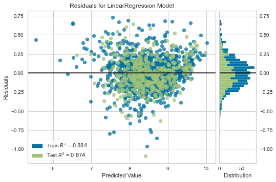

```python
plot_model(lr)
```

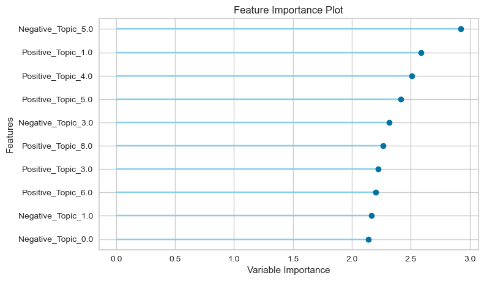

```python
# Feature Importance plot
plot_model(lr, plot = 'feature')
```

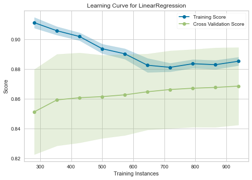

```python
# Learning Curve
plot_model(lr, plot = 'learning')
```

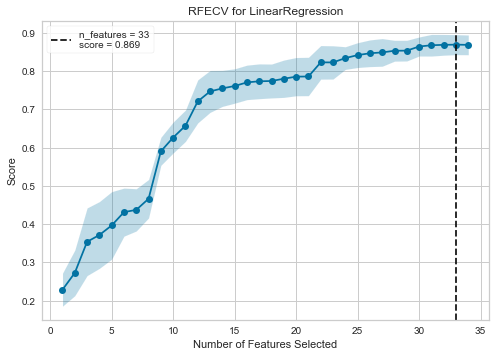

```python
# Feature Selection (recursive)
plot_model(lr, plot = 'rfe')
```

```python
evaluate_model(lr)
```

```python
lr_res = predict_model(lr)
```

|  | Model | MAE | MSE | RMSE | R2 | RMSLE | MAPE |
| --- | --- | --- | --- | --- | --- | --- | --- |
| 0 | Linear Regression | 0.1601 | 0.0433 | 0.2082 | 0.8744 | 0.0223 | 0.0191 |

```python
lr_res_summary = pull()
```

### Ridge Regression Model

```python
ridge = create_model('ridge', fold = 10)
```

|  | MAE | MSE | RMSE | R2 | RMSLE | MAPE |
| --- | --- | --- | --- | --- | --- | --- |
| 0 | 0.1884 | 0.0603 | 0.2455 | 0.8580 | 0.0282 | 0.0232 |
| 1 | 0.1750 | 0.0507 | 0.2252 | 0.8626 | 0.0244 | 0.0208 |
| 2 | 0.1836 | 0.0663 | 0.2574 | 0.8562 | 0.0283 | 0.0222 |
| 3 | 0.1729 | 0.0541 | 0.2326 | 0.8578 | 0.0259 | 0.0211 |
| 4 | 0.2023 | 0.0644 | 0.2537 | 0.8410 | 0.0272 | 0.0241 |
| 5 | 0.1866 | 0.0624 | 0.2498 | 0.8350 | 0.0270 | 0.0226 |
| 6 | 0.1983 | 0.0679 | 0.2605 | 0.8151 | 0.0272 | 0.0233 |
| 7 | 0.1640 | 0.0474 | 0.2176 | 0.8744 | 0.0238 | 0.0199 |
| 8 | 0.1489 | 0.0347 | 0.1864 | 0.9149 | 0.0202 | 0.0180 |
| 9 | 0.2130 | 0.0773 | 0.2780 | 0.8285 | 0.0312 | 0.0260 |
| Mean | 0.1833 | 0.0585 | 0.2407 | 0.8544 | 0.0263 | 0.0221 |
| SD | 0.0180 | 0.0115 | 0.0247 | 0.0263 | 0.0028 | 0.0022 |

```python
ridger = tune_model(ridge)
```

|  | MAE | MSE | RMSE | R2 | RMSLE | MAPE |
| --- | --- | --- | --- | --- | --- | --- |
| 0 | 0.1908 | 0.0627 | 0.2504 | 0.8523 | 0.0289 | 0.0235 |
| 1 | 0.1793 | 0.0530 | 0.2303 | 0.8564 | 0.0249 | 0.0213 |
| 2 | 0.1874 | 0.0688 | 0.2623 | 0.8507 | 0.0288 | 0.0226 |
| 3 | 0.1741 | 0.0549 | 0.2342 | 0.8558 | 0.0261 | 0.0213 |
| 4 | 0.2034 | 0.0654 | 0.2557 | 0.8385 | 0.0275 | 0.0243 |
| 5 | 0.1860 | 0.0626 | 0.2503 | 0.8343 | 0.0270 | 0.0225 |
| 6 | 0.2015 | 0.0689 | 0.2625 | 0.8122 | 0.0275 | 0.0237 |
| 7 | 0.1652 | 0.0483 | 0.2198 | 0.8720 | 0.0241 | 0.0201 |
| 8 | 0.1503 | 0.0355 | 0.1883 | 0.9131 | 0.0204 | 0.0182 |
| 9 | 0.2144 | 0.0778 | 0.2789 | 0.8273 | 0.0313 | 0.0262 |
| Mean | 0.1853 | 0.0598 | 0.2433 | 0.8513 | 0.0266 | 0.0224 |
| SD | 0.0181 | 0.0115 | 0.0247 | 0.0262 | 0.0028 | 0.0022 |

```python
ridge_tuned = pull()
ridge_result = ridge_tuned.iloc[[10]].rename(index={'Mean':'Ridge Regression'})
ridge_result
```

|  | MAE | MSE | RMSE | R2 | RMSLE | MAPE |
| --- | --- | --- | --- | --- | --- | --- |
| Ridge Regression | 0.1853 | 0.0598 | 0.2433 | 0.8513 | 0.0266 | 0.0224 |

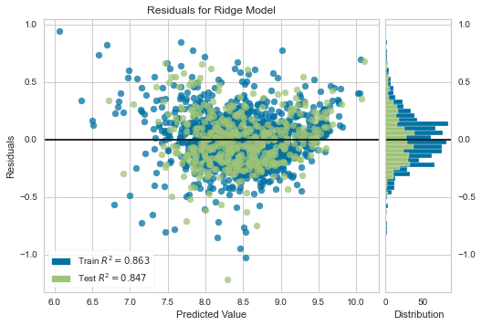

```python
plot_model(ridger)
```

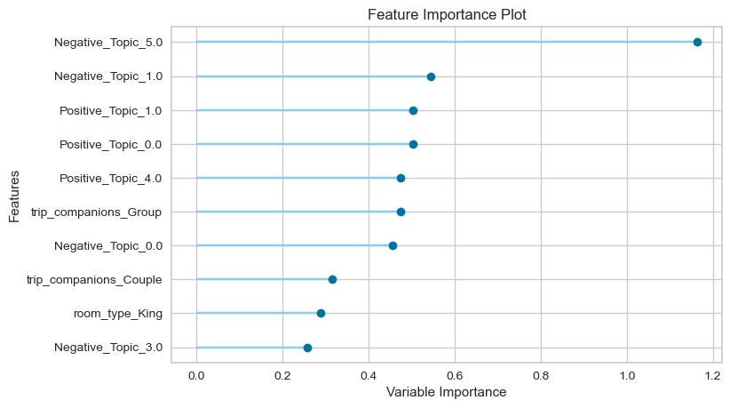

```python
# Feature Importance plot
plot_model(ridger, plot = 'feature')
```

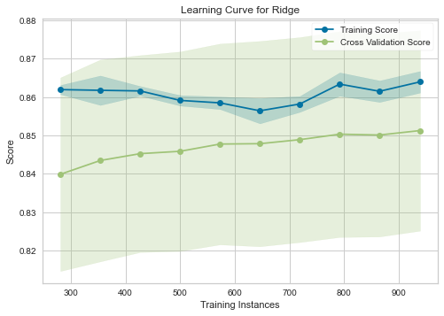

```python
# Learning Curve
plot_model(ridger, plot = 'learning')
```

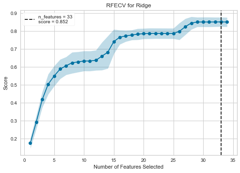

```python
# Feature Selection (recursive)
plot_model(ridger, plot = 'rfe')
```

```python
evaluate_model(ridger)
```

```python
ridge_res = predict_model(ridger)
```

|  | Model | MAE | MSE | RMSE | R2 | RMSLE | MAPE |
| --- | --- | --- | --- | --- | --- | --- | --- |
| 0 | Ridge Regression | 0.1762 | 0.0529 | 0.2299 | 0.8468 | 0.0248 | 0.0211 |

```python
ridge_res_summary = pull()
```

### Bayesian Ridge Regression

```python
bridge = create_model('br', fold = 10)
```

|  | MAE | MSE | RMSE | R2 | RMSLE | MAPE |
| --- | --- | --- | --- | --- | --- | --- |
| 0 | 0.1742 | 0.0481 | 0.2192 | 0.8868 | 0.0242 | 0.0212 |
| 1 | 0.1565 | 0.0417 | 0.2042 | 0.8871 | 0.0222 | 0.0185 |
| 2 | 0.1663 | 0.0570 | 0.2387 | 0.8764 | 0.0260 | 0.0200 |
| 3 | 0.1635 | 0.0475 | 0.2180 | 0.8751 | 0.0242 | 0.0200 |
| 4 | 0.1878 | 0.0576 | 0.2399 | 0.8578 | 0.0256 | 0.0223 |
| 5 | 0.1952 | 0.0663 | 0.2575 | 0.8247 | 0.0277 | 0.0236 |
| 6 | 0.1831 | 0.0628 | 0.2505 | 0.8290 | 0.0260 | 0.0214 |
| 7 | 0.1699 | 0.0482 | 0.2196 | 0.8721 | 0.0239 | 0.0206 |
| 8 | 0.1456 | 0.0338 | 0.1838 | 0.9172 | 0.0200 | 0.0176 |
| 9 | 0.1917 | 0.0643 | 0.2535 | 0.8574 | 0.0285 | 0.0234 |
| Mean | 0.1734 | 0.0527 | 0.2285 | 0.8684 | 0.0249 | 0.0209 |
| SD | 0.0153 | 0.0100 | 0.0225 | 0.0263 | 0.0024 | 0.0018 |

```python
bridger = tune_model(bridge, n_iter = 50)
```

|  | MAE | MSE | RMSE | R2 | RMSLE | MAPE |
| --- | --- | --- | --- | --- | --- | --- |
| 0 | 0.1718 | 0.0469 | 0.2167 | 0.8894 | 0.0238 | 0.0208 |
| 1 | 0.1557 | 0.0409 | 0.2023 | 0.8892 | 0.0220 | 0.0184 |
| 2 | 0.1649 | 0.0572 | 0.2392 | 0.8758 | 0.0261 | 0.0198 |
| 3 | 0.1620 | 0.0462 | 0.2148 | 0.8787 | 0.0239 | 0.0198 |
| 4 | 0.1853 | 0.0565 | 0.2378 | 0.8603 | 0.0254 | 0.0220 |
| 5 | 0.1969 | 0.0677 | 0.2603 | 0.8209 | 0.0280 | 0.0238 |
| 6 | 0.1822 | 0.0623 | 0.2496 | 0.8303 | 0.0259 | 0.0213 |
| 7 | 0.1719 | 0.0494 | 0.2223 | 0.8690 | 0.0242 | 0.0208 |
| 8 | 0.1475 | 0.0345 | 0.1857 | 0.9155 | 0.0203 | 0.0179 |
| 9 | 0.1849 | 0.0598 | 0.2446 | 0.8672 | 0.0276 | 0.0226 |
| Mean | 0.1723 | 0.0522 | 0.2273 | 0.8696 | 0.0247 | 0.0207 |
| SD | 0.0144 | 0.0098 | 0.0219 | 0.0265 | 0.0023 | 0.0017 |

```python
bridge_tuned = pull()
bridge_result = bridge_tuned.iloc[[10]].rename(index={'Mean':'Bayesian Ridge Regression'})
bridge_result
```

|  | MAE | MSE | RMSE | R2 | RMSLE | MAPE |
| --- | --- | --- | --- | --- | --- | --- |
| Bayesian Ridge Regression | 0.1723 | 0.0522 | 0.2273 | 0.8696 | 0.0247 | 0.0207 |

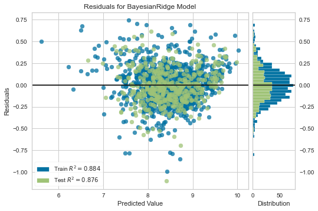

```python
plot_model(bridger)
```

```python
# Hyperparameters
plot_model(bridger, plot = 'parameter')
```

|  | Parameters |
| --- | --- |
| alpha_1 | 0.001 |
| alpha_2 | 1e-06 |
| alpha_init | None |
| compute_score | False |
| copy_X | True |
| fit_intercept | True |
| lambda_1 | 0.005 |
| lambda_2 | 0.3 |
| lambda_init | None |
| n_iter | 300 |
| normalize | True |
| tol | 0.001 |
| verbose | False |

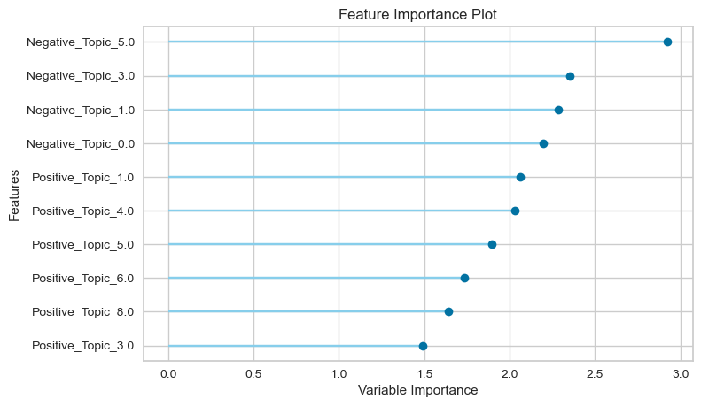

```python
# Feature Importance plot
plot_model(bridger, plot = 'feature')
```

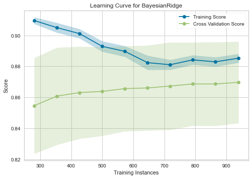

```python
# Learning Curve
plot_model(bridger, plot = 'learning')
```

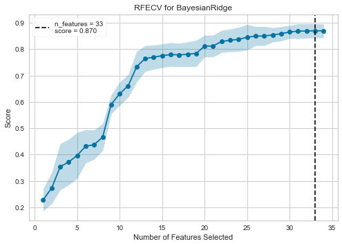

```python
# Feature Selection (recursive)
plot_model(bridger, plot = 'rfe')
```

```python
evaluate_model(bridger)
```

```python
bridge_res = predict_model(bridger)
```

|  | Model | MAE | MSE | RMSE | R2 | RMSLE | MAPE |
| --- | --- | --- | --- | --- | --- | --- | --- |
| 0 | Bayesian Ridge | 0.1589 | 0.0429 | 0.2072 | 0.8756 | 0.0222 | 0.0190 |

```python
bridge_res_summary = pull()
```

### Decision Tree Model

```python
dt = create_model('dt', fold = 10)
```

|  | MAE | MSE | RMSE | R2 | RMSLE | MAPE |
| --- | --- | --- | --- | --- | --- | --- |
| 0 | 0.3021 | 0.1553 | 0.3941 | 0.6341 | 0.0439 | 0.0370 |
| 1 | 0.2227 | 0.0838 | 0.2895 | 0.7730 | 0.0306 | 0.0263 |
| 2 | 0.2752 | 0.1634 | 0.4043 | 0.6453 | 0.0443 | 0.0330 |
| 3 | 0.2924 | 0.1293 | 0.3595 | 0.6604 | 0.0398 | 0.0355 |
| 4 | 0.3005 | 0.1458 | 0.3818 | 0.6399 | 0.0403 | 0.0355 |
| 5 | 0.2664 | 0.1299 | 0.3604 | 0.6565 | 0.0389 | 0.0324 |
| 6 | 0.2728 | 0.1282 | 0.3581 | 0.6506 | 0.0393 | 0.0328 |
| 7 | 0.2534 | 0.1086 | 0.3295 | 0.7123 | 0.0363 | 0.0307 |
| 8 | 0.2593 | 0.1041 | 0.3227 | 0.7447 | 0.0349 | 0.0313 |
| 9 | 0.2835 | 0.1573 | 0.3966 | 0.6508 | 0.0435 | 0.0341 |
| Mean | 0.2728 | 0.1306 | 0.3597 | 0.6768 | 0.0392 | 0.0329 |
| SD | 0.0229 | 0.0245 | 0.0350 | 0.0462 | 0.0041 | 0.0029 |

```python
dtr = tune_model(dt, n_iter = 50)
```

|  | MAE | MSE | RMSE | R2 | RMSLE | MAPE |
| --- | --- | --- | --- | --- | --- | --- |
| 0 | 0.2464 | 0.1016 | 0.3188 | 0.7606 | 0.0357 | 0.0302 |
| 1 | 0.2153 | 0.0744 | 0.2727 | 0.7986 | 0.0293 | 0.0256 |
| 2 | 0.2310 | 0.1023 | 0.3199 | 0.7780 | 0.0354 | 0.0280 |
| 3 | 0.2401 | 0.0903 | 0.3005 | 0.7628 | 0.0332 | 0.0293 |
| 4 | 0.2971 | 0.1450 | 0.3808 | 0.6419 | 0.0409 | 0.0356 |
| 5 | 0.2552 | 0.1114 | 0.3337 | 0.7055 | 0.0362 | 0.0310 |
| 6 | 0.2496 | 0.1002 | 0.3165 | 0.7270 | 0.0344 | 0.0300 |
| 7 | 0.2319 | 0.1009 | 0.3176 | 0.7327 | 0.0348 | 0.0285 |
| 8 | 0.2184 | 0.0807 | 0.2841 | 0.8021 | 0.0310 | 0.0266 |
| 9 | 0.2387 | 0.1088 | 0.3299 | 0.7584 | 0.0357 | 0.0288 |
| Mean | 0.2424 | 0.1016 | 0.3174 | 0.7468 | 0.0347 | 0.0294 |
| SD | 0.0219 | 0.0183 | 0.0280 | 0.0454 | 0.0030 | 0.0026 |

```python
dt_tuned = pull()
dt_result = dt_tuned.iloc[[10]].rename(index={'Mean':'Decision Tree'})
dt_result
```

|  | MAE | MSE | RMSE | R2 | RMSLE | MAPE |
| --- | --- | --- | --- | --- | --- | --- |
| Decision Tree | 0.2424 | 0.1016 | 0.3174 | 0.7468 | 0.0347 | 0.0294 |

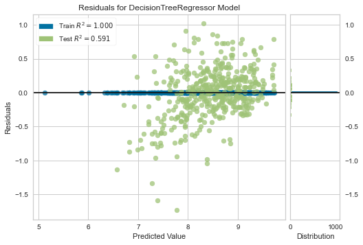

```python
plot_model(dt)
```

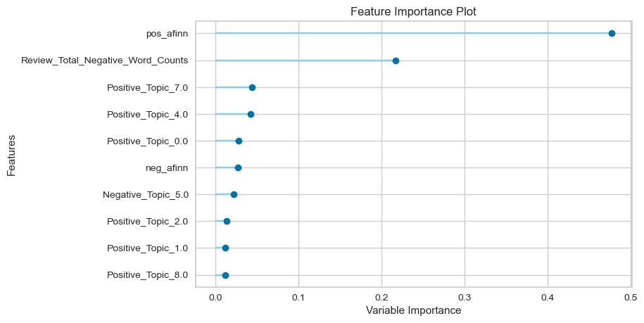

```python
# Feature Importance plot
plot_model(dtr, plot = 'feature')
```

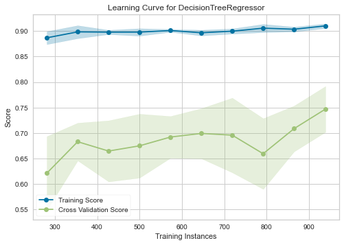

```python
# Learning Curve
plot_model(dtr, plot = 'learning')
```

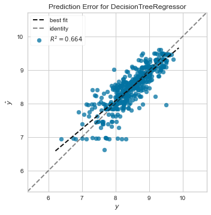

```python
# Prediction Fit/Error
plot_model(dtr, plot = 'error')
```

```python
# Hyperparameters
plot_model(dtr, plot = 'parameter')
```

|  | Parameters |
| --- | --- |
| ccp_alpha | 0.0 |
| criterion | mae |
| max_depth | 12 |
| max_features | 1.0 |
| max_leaf_nodes | None |
| min_impurity_decrease | 0.0001 |
| min_impurity_split | None |
| min_samples_leaf | 6 |
| min_samples_split | 5 |
| min_weight_fraction_leaf | 0.0 |
| presort | deprecated |
| random_state | 456 |
| splitter | best |

```python
dtr
```

```
DecisionTreeRegressor(ccp_alpha=0.0, criterion='mae', max_depth=12,
                      max_features=1.0, max_leaf_nodes=None,
                      min_impurity_decrease=0.0001, min_impurity_split=None,
                      min_samples_leaf=6, min_samples_split=5,
                      min_weight_fraction_leaf=0.0, presort='deprecated',
                      random_state=456, splitter='best')
```

```python
evaluate_model(dtr)
```

```python
dt_res = predict_model(dtr)
```

|  | Model | MAE | MSE | RMSE | R2 | RMSLE | MAPE |
| --- | --- | --- | --- | --- | --- | --- | --- |
| 0 | Decision Tree Regressor | 0.2499 | 0.1158 | 0.3403 | 0.6643 | 0.0374 | 0.0302 |

```python
dt_res_summary = pull()
```

### Random Forest Model

```python
rf = create_model('rf', fold = 10)
```

|  | MAE | MSE | RMSE | R2 | RMSLE | MAPE |
| --- | --- | --- | --- | --- | --- | --- |
| 0 | 0.1968 | 0.0671 | 0.2591 | 0.8419 | 0.0309 | 0.0245 |
| 1 | 0.1780 | 0.0520 | 0.2281 | 0.8591 | 0.0242 | 0.0210 |
| 2 | 0.1845 | 0.0638 | 0.2525 | 0.8616 | 0.0280 | 0.0224 |
| 3 | 0.1822 | 0.0591 | 0.2432 | 0.8446 | 0.0276 | 0.0225 |
| 4 | 0.2143 | 0.0706 | 0.2658 | 0.8256 | 0.0287 | 0.0257 |
| 5 | 0.1841 | 0.0722 | 0.2687 | 0.8091 | 0.0291 | 0.0224 |
| 6 | 0.1893 | 0.0639 | 0.2529 | 0.8258 | 0.0270 | 0.0224 |
| 7 | 0.1976 | 0.0659 | 0.2567 | 0.8253 | 0.0284 | 0.0244 |
| 8 | 0.1582 | 0.0392 | 0.1981 | 0.9038 | 0.0216 | 0.0192 |
| 9 | 0.2075 | 0.0810 | 0.2846 | 0.8202 | 0.0317 | 0.0254 |
| Mean | 0.1892 | 0.0635 | 0.2510 | 0.8417 | 0.0277 | 0.0230 |
| SD | 0.0151 | 0.0109 | 0.0227 | 0.0262 | 0.0028 | 0.0019 |

```python
rfr = tune_model(rf, n_iter = 50)
```

|  | MAE | MSE | RMSE | R2 | RMSLE | MAPE |
| --- | --- | --- | --- | --- | --- | --- |
| 0 | 0.1994 | 0.0697 | 0.2640 | 0.8359 | 0.0313 | 0.0248 |
| 1 | 0.1829 | 0.0550 | 0.2345 | 0.8510 | 0.0248 | 0.0216 |
| 2 | 0.1929 | 0.0673 | 0.2593 | 0.8540 | 0.0288 | 0.0234 |
| 3 | 0.1863 | 0.0612 | 0.2475 | 0.8391 | 0.0280 | 0.0230 |
| 4 | 0.2183 | 0.0749 | 0.2737 | 0.8149 | 0.0296 | 0.0262 |
| 5 | 0.1909 | 0.0745 | 0.2729 | 0.8030 | 0.0295 | 0.0232 |
| 6 | 0.1955 | 0.0661 | 0.2571 | 0.8200 | 0.0275 | 0.0232 |
| 7 | 0.1996 | 0.0679 | 0.2606 | 0.8201 | 0.0286 | 0.0245 |
| 8 | 0.1654 | 0.0421 | 0.2052 | 0.8968 | 0.0224 | 0.0201 |
| 9 | 0.2108 | 0.0826 | 0.2874 | 0.8166 | 0.0319 | 0.0258 |
| Mean | 0.1942 | 0.0661 | 0.2562 | 0.8351 | 0.0282 | 0.0236 |
| SD | 0.0139 | 0.0108 | 0.0219 | 0.0258 | 0.0027 | 0.0018 |

```python
rf_tuned = pull()
rf_result =rf_tuned.iloc[[10]].rename(index={'Mean':'Random Forest'})
rf_result
```

|  | MAE | MSE | RMSE | R2 | RMSLE | MAPE |
| --- | --- | --- | --- | --- | --- | --- |
| Random Forest | 0.1942 | 0.0661 | 0.2562 | 0.8351 | 0.0282 | 0.0236 |

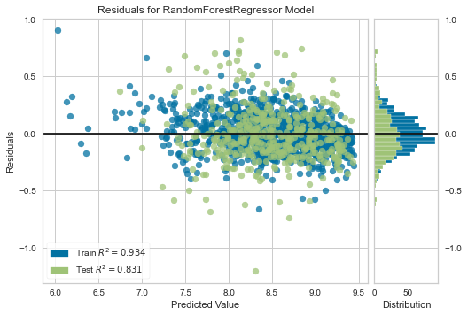

```python
plot_model(rfr)
```

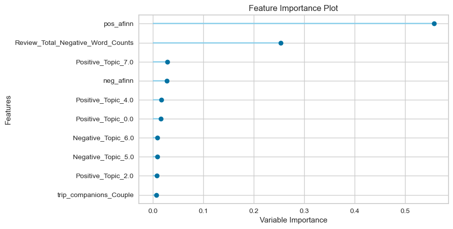

```python
# Feature Importance plot
plot_model(rfr, plot = 'feature')
```

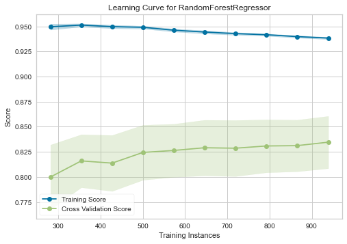

```python
# Learning Curve
plot_model(rfr, plot = 'learning')
```

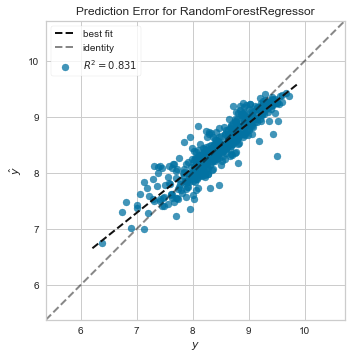

```python
# Prediction Fit/Error
plot_model(rfr, plot = 'error')
```

```python
# Hyperparameters
plot_model(rfr, plot = 'parameter')
```

|  | Parameters |
| --- | --- |
| bootstrap | True |
| ccp_alpha | 0.0 |
| criterion | mse |
| max_depth | 11 |
| max_features | 1.0 |
| max_leaf_nodes | None |
| max_samples | None |
| min_impurity_decrease | 0.0005 |
| min_impurity_split | None |
| min_samples_leaf | 2 |
| min_samples_split | 7 |
| min_weight_fraction_leaf | 0.0 |
| n_estimators | 190 |
| n_jobs | 4 |
| oob_score | False |
| random_state | 456 |
| verbose | 0 |
| warm_start | False |

```python
rfr
```

```
RandomForestRegressor(bootstrap=True, ccp_alpha=0.0, criterion='mse',
                      max_depth=11, max_features=1.0, max_leaf_nodes=None,
                      max_samples=None, min_impurity_decrease=0.0005,
                      min_impurity_split=None, min_samples_leaf=2,
                      min_samples_split=7, min_weight_fraction_leaf=0.0,
                      n_estimators=190, n_jobs=4, oob_score=False,
                      random_state=456, verbose=0, warm_start=False)
```

```python
evaluate_model(rfr)
```

```python
rf_res = predict_model(rfr)
```

|  | Model | MAE | MSE | RMSE | R2 | RMSLE | MAPE |
| --- | --- | --- | --- | --- | --- | --- | --- |
| 0 | Random Forest Regressor | 0.1797 | 0.0584 | 0.2417 | 0.8306 | 0.0262 | 0.0216 |

```python
rf_res_summary = pull()
```

### Gradient Boost Regression Model

```python
gbr = create_model('gbr', fold = 10)
```

|  | MAE | MSE | RMSE | R2 | RMSLE | MAPE |
| --- | --- | --- | --- | --- | --- | --- |
| 0 | 0.1788 | 0.0595 | 0.2440 | 0.8598 | 0.0281 | 0.0221 |
| 1 | 0.1706 | 0.0495 | 0.2224 | 0.8660 | 0.0236 | 0.0202 |
| 2 | 0.1706 | 0.0515 | 0.2268 | 0.8883 | 0.0253 | 0.0208 |
| 3 | 0.1770 | 0.0573 | 0.2393 | 0.8495 | 0.0273 | 0.0220 |
| 4 | 0.1832 | 0.0593 | 0.2435 | 0.8536 | 0.0261 | 0.0218 |
| 5 | 0.1703 | 0.0647 | 0.2544 | 0.8289 | 0.0272 | 0.0205 |
| 6 | 0.1767 | 0.0566 | 0.2380 | 0.8457 | 0.0257 | 0.0211 |
| 7 | 0.1728 | 0.0568 | 0.2384 | 0.8493 | 0.0260 | 0.0211 |
| 8 | 0.1523 | 0.0356 | 0.1887 | 0.9127 | 0.0204 | 0.0183 |
| 9 | 0.2015 | 0.0775 | 0.2784 | 0.8280 | 0.0311 | 0.0247 |
| Mean | 0.1754 | 0.0568 | 0.2374 | 0.8582 | 0.0261 | 0.0213 |
| SD | 0.0117 | 0.0102 | 0.0218 | 0.0246 | 0.0027 | 0.0016 |

```python
gbrr = tune_model(gbr, n_iter = 50)
```

|  | MAE | MSE | RMSE | R2 | RMSLE | MAPE |
| --- | --- | --- | --- | --- | --- | --- |
| 0 | 0.1851 | 0.0650 | 0.2549 | 0.8470 | 0.0296 | 0.0229 |
| 1 | 0.1701 | 0.0483 | 0.2197 | 0.8693 | 0.0235 | 0.0202 |
| 2 | 0.1661 | 0.0537 | 0.2317 | 0.8835 | 0.0258 | 0.0202 |
| 3 | 0.1648 | 0.0450 | 0.2122 | 0.8817 | 0.0238 | 0.0202 |
| 4 | 0.1839 | 0.0583 | 0.2414 | 0.8560 | 0.0257 | 0.0218 |
| 5 | 0.1884 | 0.0726 | 0.2694 | 0.8081 | 0.0289 | 0.0227 |
| 6 | 0.1779 | 0.0593 | 0.2435 | 0.8384 | 0.0264 | 0.0212 |
| 7 | 0.1802 | 0.0603 | 0.2455 | 0.8402 | 0.0264 | 0.0219 |
| 8 | 0.1656 | 0.0417 | 0.2042 | 0.8978 | 0.0220 | 0.0199 |
| 9 | 0.1971 | 0.0703 | 0.2651 | 0.8440 | 0.0293 | 0.0239 |
| Mean | 0.1779 | 0.0574 | 0.2388 | 0.8566 | 0.0262 | 0.0215 |
| SD | 0.0105 | 0.0098 | 0.0207 | 0.0253 | 0.0025 | 0.0013 |

```python
gbr_tuned = pull()
gbr_result =gbr_tuned.iloc[[10]].rename(index={'Mean':'Gradient Boost Regression'})
gbr_result
```

|  | MAE | MSE | RMSE | R2 | RMSLE | MAPE |
| --- | --- | --- | --- | --- | --- | --- |
| Gradient Boost Regression | 0.1779 | 0.0574 | 0.2388 | 0.8566 | 0.0262 | 0.0215 |

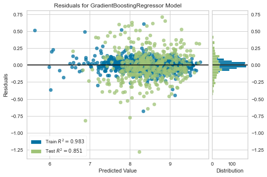

```python
plot_model(gbrr)
```

```python
gbrr
```

```
GradientBoostingRegressor(alpha=0.9, ccp_alpha=0.0, criterion='friedman_mse',
                          init=None, learning_rate=0.069, loss='ls',
                          max_depth=10, max_features=1.0, max_leaf_nodes=None,
                          min_impurity_decrease=0.001, min_impurity_split=None,
                          min_samples_leaf=4, min_samples_split=9,
                          min_weight_fraction_leaf=0.0, n_estimators=130,
                          n_iter_no_change=None, presort='deprecated',
                          random_state=456, subsample=0.25, tol=0.0001,
                          validation_fraction=0.1, verbose=0, warm_start=False)
```

```python
evaluate_model(gbrr)
```

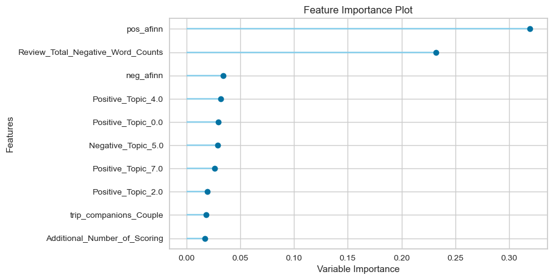

```python
# Feature Importance plot
plot_model(gbrr, plot = 'feature')
```

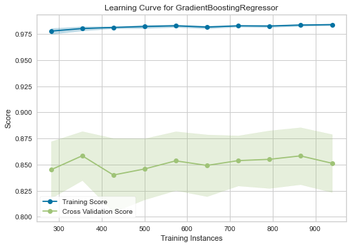

```python
# Learning Curve
plot_model(gbrr, plot = 'learning')
```

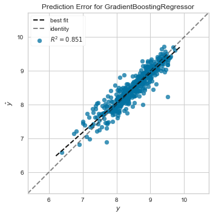

```python
# Prediction Fit/Error
plot_model(gbrr, plot = 'error')
```

```python
# Hyperparameters
plot_model(gbrr, plot = 'parameter')
```

|  | Parameters |
| --- | --- |
| alpha | 0.9 |
| ccp_alpha | 0.0 |
| criterion | friedman_mse |
| init | None |
| learning_rate | 0.069 |
| loss | ls |
| max_depth | 10 |
| max_features | 1.0 |
| max_leaf_nodes | None |
| min_impurity_decrease | 0.001 |
| min_impurity_split | None |
| min_samples_leaf | 4 |
| min_samples_split | 9 |
| min_weight_fraction_leaf | 0.0 |
| n_estimators | 130 |
| n_iter_no_change | None |
| presort | deprecated |
| random_state | 456 |
| subsample | 0.25 |
| tol | 0.0001 |
| validation_fraction | 0.1 |
| verbose | 0 |
| warm_start | False |

```python
gbr_res = predict_model(gbrr)
```

|  | Model | MAE | MSE | RMSE | R2 | RMSLE | MAPE |
| --- | --- | --- | --- | --- | --- | --- | --- |
| 0 | Gradient Boosting Regressor | 0.1672 | 0.0513 | 0.2266 | 0.8512 | 0.0245 | 0.0201 |

```python
gbr_res_summary = pull()
```

### Stacked Ensemble Model

```python
stacked_models = stack_models(estimator_list = [lr, bridger, rfr, gbrr])
```

|  | MAE | MSE | RMSE | R2 | RMSLE | MAPE |
| --- | --- | --- | --- | --- | --- | --- |
| 0 | 0.1668 | 0.0430 | 0.2073 | 0.8988 | 0.0229 | 0.0203 |
| 1 | 0.1468 | 0.0367 | 0.1915 | 0.9006 | 0.0207 | 0.0174 |
| 2 | 0.1551 | 0.0488 | 0.2208 | 0.8942 | 0.0241 | 0.0188 |
| 3 | 0.1455 | 0.0393 | 0.1983 | 0.8967 | 0.0222 | 0.0178 |
| 4 | 0.1786 | 0.0544 | 0.2332 | 0.8656 | 0.0249 | 0.0212 |
| 5 | 0.1843 | 0.0620 | 0.2491 | 0.8360 | 0.0267 | 0.0222 |
| 6 | 0.1753 | 0.0548 | 0.2340 | 0.8508 | 0.0247 | 0.0207 |
| 7 | 0.1660 | 0.0472 | 0.2173 | 0.8748 | 0.0236 | 0.0201 |
| 8 | 0.1371 | 0.0290 | 0.1702 | 0.9290 | 0.0185 | 0.0165 |
| 9 | 0.1730 | 0.0514 | 0.2267 | 0.8859 | 0.0253 | 0.0211 |
| Mean | 0.1628 | 0.0467 | 0.2149 | 0.8832 | 0.0234 | 0.0196 |
| SD | 0.0151 | 0.0093 | 0.0222 | 0.0257 | 0.0023 | 0.0018 |

```python
smr = tune_model(stacked_models, n_iter = 50)
```

|  | MAE | MSE | RMSE | R2 | RMSLE | MAPE |
| --- | --- | --- | --- | --- | --- | --- |
| 0 | 0.1668 | 0.0430 | 0.2073 | 0.8988 | 0.0229 | 0.0203 |
| 1 | 0.1468 | 0.0367 | 0.1915 | 0.9006 | 0.0207 | 0.0174 |
| 2 | 0.1551 | 0.0488 | 0.2208 | 0.8942 | 0.0241 | 0.0188 |
| 3 | 0.1455 | 0.0393 | 0.1983 | 0.8967 | 0.0222 | 0.0178 |
| 4 | 0.1786 | 0.0544 | 0.2332 | 0.8656 | 0.0249 | 0.0212 |
| 5 | 0.1843 | 0.0620 | 0.2491 | 0.8360 | 0.0267 | 0.0222 |
| 6 | 0.1753 | 0.0548 | 0.2340 | 0.8508 | 0.0247 | 0.0207 |
| 7 | 0.1660 | 0.0472 | 0.2173 | 0.8748 | 0.0236 | 0.0201 |
| 8 | 0.1371 | 0.0290 | 0.1702 | 0.9290 | 0.0185 | 0.0165 |
| 9 | 0.1730 | 0.0514 | 0.2267 | 0.8859 | 0.0253 | 0.0211 |
| Mean | 0.1628 | 0.0467 | 0.2149 | 0.8832 | 0.0234 | 0.0196 |
| SD | 0.0151 | 0.0093 | 0.0222 | 0.0257 | 0.0023 | 0.0018 |

```python
stacked_tuned = pull()
stacked_result = stacked_tuned.iloc[[10]].rename(index={'Mean':'Stacked Models'})
stacked_result
```

|  | MAE | MSE | RMSE | R2 | RMSLE | MAPE |
| --- | --- | --- | --- | --- | --- | --- |
| Stacked Models | 0.1628 | 0.0467 | 0.2149 | 0.8832 | 0.0234 | 0.0196 |

```python
evaluate_model(smr)
```

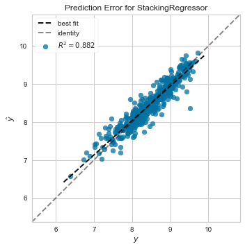

```python
# Prediction Fit/Error
plot_model(smr, plot = 'error')
```

```python
# Hyperparameters
plot_model(smr, plot = 'parameter')
```

|  | Parameters |
| --- | --- |
| cv | KFold(n_splits=10, random_state=456, shuffle=F... |
| estimators | [('lr', LinearRegression(copy_X=True, fit_inte... |
| final_estimator | LinearRegression(copy_X=True, fit_intercept=Tr... |
| n_jobs | 4 |
| passthrough | True |
| verbose | 0 |

```python
smr
```

```
StackingRegressor(cv=KFold(n_splits=10, random_state=456, shuffle=False),
                  estimators=[('lr',
                               LinearRegression(copy_X=True, fit_intercept=True,
                                                n_jobs=4, normalize=False)),
                              ('br',
                               BayesianRidge(alpha_1=0.001, alpha_2=1e-06,
                                             alpha_init=None,
                                             compute_score=False, copy_X=True,
                                             fit_intercept=True, lambda_1=0.005,
                                             lambda_2=0.3, lambda_init=None,
                                             n_iter=300, normalize=True,...
                                                         min_samples_leaf=4,
                                                         min_samples_split=9,
                                                         min_weight_fraction_leaf=0.0,
                                                         n_estimators=130,
                                                         n_iter_no_change=None,
                                                         presort='deprecated',
                                                         random_state=456,
                                                         subsample=0.25,
                                                         tol=0.0001,
                                                         validation_fraction=0.1,
                                                         verbose=0,
                                                         warm_start=False))],
                  final_estimator=LinearRegression(copy_X=True,
                                                   fit_intercept=True, n_jobs=4,
                                                   normalize=True),
                  n_jobs=4, passthrough=True, verbose=0)
```

```python
stacked_res = predict_model(smr)
```

|  | Model | MAE | MSE | RMSE | R2 | RMSLE | MAPE |
| --- | --- | --- | --- | --- | --- | --- | --- |
| 0 | Stacking Regressor | 0.1508 | 0.0407 | 0.2018 | 0.8820 | 0.0217 | 0.0181 |

```python
stacked_res_summary = pull()
```

### Neural Network Model

```python
from sklearn.model_selection import train_test_split
from sklearn.preprocessing import StandardScaler
from sklearn.metrics import r2_score, mean_squared_error
```

```python
import tensorflow as tf
from tensorflow.keras import backend as K
from tensorflow.keras import layers
from tensorflow.keras.models import Sequential
from tensorflow.keras.layers import Dense, Activation
from tensorflow.keras.callbacks import EarlyStopping
```

```python
# Train-test split
X = data_4.drop(columns = ['Reviewer_Score'], axis = 1)
y = data_4['Reviewer_Score']

X_train, X_test, y_train, y_test = train_test_split(X, y, test_size = 0.2, random_state = 421)
```

```python
print(X_train.shape)
print(y_train.shape)
```

```
(1193, 34)
(1193,)
```

```python
# Standardise the X variables
scaler = StandardScaler()
scaler.fit(X_train)

X_train_ss = scaler.transform(X_train)
X_test_ss  = scaler.transform(X_test)
```

```python
random.seed(4211)
```

```python
# Build the Neural Network
model_n = Sequential(name = 'Basic')

# Input Layer
model_n.add(Dense(8, input_shape = (X_train_ss.shape[1], ), activation = 'relu'))

# Hidden Layer 1
model_n.add(Dense(4, activation = 'relu'))

# Output Layer
model_n.add(Dense(1, activation = 'linear'))
```

```python
model_n.summary()
```

```
Model: "Basic"
_________________________________________________________________
Layer (type)                 Output Shape              Param #
=================================================================
dense_21 (Dense)             (None, 8)                 280
_________________________________________________________________
dense_22 (Dense)             (None, 4)                 36
_________________________________________________________________
dense_23 (Dense)             (None, 1)                 5
=================================================================
Total params: 321
Trainable params: 321
Non-trainable params: 0
_________________________________________________________________
```

```python
def R2(y_true, y_pred):
    SS_res = K.sum(K.square(y_true - y_pred))
    SS_tot = K.sum(K.square(y_true - K.mean(y_true)))
    return (1 - SS_res/(SS_tot + K.epsilon()))
```

```python
# Compile NN model
model_n.compile(loss = 'mse',
                optimizer = tf.keras.optimizers.Adam(lr = 0.1),
                metrics = [R2])
```

```python
# Fit and train NN model
training = model_n.fit(X_train_ss,
                       y_train,
                       epochs = 200,
                       batch_size = 100,
                       validation_split = 0.20,
                       callbacks = [EarlyStopping(monitor = 'val_loss',
                                                  mode = 'min',
                                                  patience = 80)],
                       shuffle = True)
```

```python
def plot_the_loss_curve(mse_train, mse_val):
    """Plot a curve of loss vs. epoch."""

    plt.figure(figsize = (10, 8))
    plt.xlabel("Epoch")
    plt.ylabel("MSE Loss")

    plt.plot(mse_train, label = "Training Loss")
    plt.plot(mse_val,   label = "Validation Loss")
    plt.legend()

    plt.show()
```

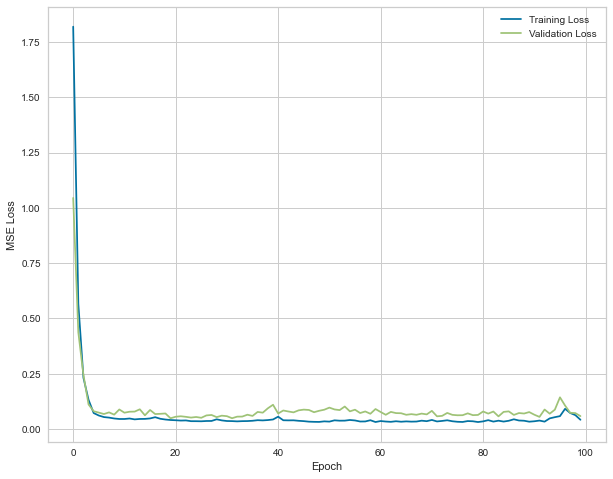

```python
plot_the_loss_curve(training.history['loss'], training.history['val_loss'])
```

```python
# In-sample CV Performance
nn_in_result = pd.DataFrame({'Model': ['Neural Network'],
                             'RMSE': [(training.history['val_loss'][-1])**0.5],
                             'R2': [training.history['val_R2'][-1]]})
nn_in_result
```

|  | Model | RMSE | R2 |
| --- | --- | --- | --- |
| 0 | Neural Network | 0.241617 | 0.861177 |

```python
# Get predictions for NN
y_pred_nn = model_n.predict(X_test_ss)
```

```python
# Out-of-sample Performance for NN
nn_out_result = pd.DataFrame({'Model': ['Neural Network'],
                              'RMSE': [mean_squared_error(y_test, y_pred_nn)**0.5],
                              'R2': [r2_score(y_test, y_pred_nn)]})
nn_out_result
```

|  | Model | RMSE | R2 |
| --- | --- | --- | --- |
| 0 | Neural Network | 0.227529 | 0.861197 |

## Model Performance Summary

### In-Sample CV Performance

```python
pd.concat([lr_result, ridge_result,bridge_result, dt_result, rf_result, gbr_result, stacked_result])
```

|  | MAE | MSE | RMSE | R2 | RMSLE | MAPE |
| --- | --- | --- | --- | --- | --- | --- |
| Linear Regression | 0.1736 | 0.0526 | 0.2283 | 0.8686 | 0.0248 | 0.0209 |
| Ridge Regression | 0.1853 | 0.0598 | 0.2433 | 0.8513 | 0.0266 | 0.0224 |
| Bayesian Ridge Regression | 0.1723 | 0.0522 | 0.2273 | 0.8696 | 0.0247 | 0.0207 |
| Decision Tree | 0.2424 | 0.1016 | 0.3174 | 0.7468 | 0.0347 | 0.0294 |
| Random Forest | 0.1942 | 0.0661 | 0.2562 | 0.8351 | 0.0282 | 0.0236 |
| Gradient Boost Regression | 0.1779 | 0.0574 | 0.2388 | 0.8566 | 0.0262 | 0.0215 |
| Stacked Models | 0.1628 | 0.0467 | 0.2149 | 0.8832 | 0.0234 | 0.0196 |

### Out-of-sample (Test) Performance

```python
pd.concat([lr_res_summary, dt_res_summary, ridge_res_summary, bridge_res_summary, rf_res_summary, gbr_res_summary, stacked_res_summary])
```

|  | Model | MAE | MSE | RMSE | R2 | RMSLE | MAPE |
| --- | --- | --- | --- | --- | --- | --- | --- |
| 0 | Linear Regression | 0.1601 | 0.0433 | 0.2082 | 0.8744 | 0.0223 | 0.0191 |
| 0 | Decision Tree Regressor | 0.2499 | 0.1158 | 0.3403 | 0.6643 | 0.0374 | 0.0302 |
| 0 | Ridge Regression | 0.1762 | 0.0529 | 0.2299 | 0.8468 | 0.0248 | 0.0211 |
| 0 | Bayesian Ridge | 0.1589 | 0.0429 | 0.2072 | 0.8756 | 0.0222 | 0.0190 |
| 0 | Random Forest Regressor | 0.1797 | 0.0584 | 0.2417 | 0.8306 | 0.0262 | 0.0216 |
| 0 | Gradient Boosting Regressor | 0.1672 | 0.0513 | 0.2266 | 0.8512 | 0.0245 | 0.0201 |
| 0 | Stacking Regressor | 0.1508 | 0.0407 | 0.2018 | 0.8820 | 0.0217 | 0.0181 |